# Homework #5: Density Estimation

Jie Tang

Due: Tue Mar 22 | 10:30 am

**SYS 4582/6018 | Spring 2022 | University of Virginia**

# Required R packages and Directories

```r
data.dir = 'https://mdporter.github.io/SYS6018/data/' # data directory
batdata.dir = ' https://mdporter.github.io/SYS6018/data//geo_profile.csv'
library(R6018)     # functions for SYS 6018
library(ks)        # functions for KDE
library(tidyverse) # functions for data manipulation
```

# Problem 1 Geographic Profiling

Geographic profiling, a method developed in criminology, can be used to estimate the [home location (roost) of animals](https://www.sciencedirect.com/science/article/pii/S0022519305004157) based on a collection of sightings. The approach requires an estimate of the distribution the animal will travel from their roost to forage for food.

A sample of $283$ distances that pipistrelle bats traveled (in meters) from their roost can be found at:

- **Bat Data**: https://mdporter.github.io/SYS6018/data//geo_profile.csv

One probability model for the distance these bats will travel is:
$$\begin{align*}
f(x; \theta) = \frac{x}{\theta} \exp \left( - \frac{x^2}{2 \theta} \right)
\end{align*}$$
where the parameter $\theta > 0$ controls how far they are willing to travel.

## b. What is the MLE of $\theta$ for the bat data? (Use results from a, or use computational methods.)

```r
batdata = read.csv('geo_profile.csv', header=FALSE)
head(batdata)
```

|  | V1 |
| --- | --- |
| 1 | 2.582 |
| 2 | 2.109 |
| 3 | 5.354 |
| 4 | 3.867 |
| 5 | 2.851 |
| 6 | 2.710 |

```r
x = batdata$V1
#mle
mle = sum(x^2)/(2*length(x))
```

## c. Using the MLE value of $\theta$ from part b, compute the estimated density at a set of evaluation points between 0 and 8 meters. Plot the estimated density.

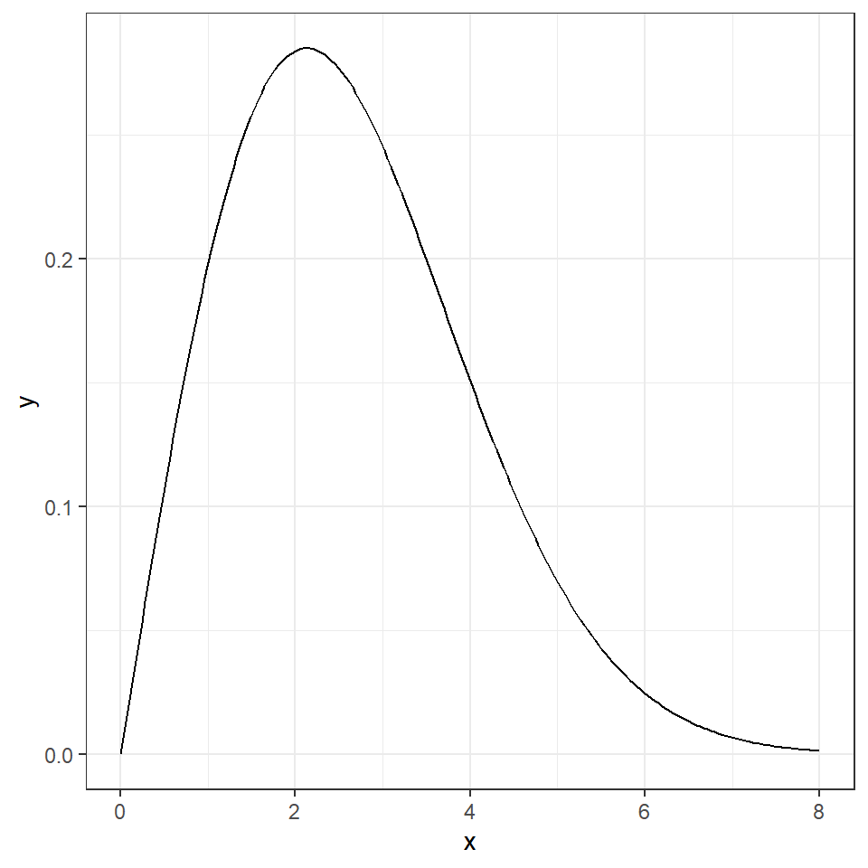

```r
theta = mle
x = seq(0, 8, length=200)
outcome = tibble(x = x, y = (x/theta) * exp(-x^2/(2*theta)))
ggplot(outcome, aes(x, y)) + geom_line()
```

```r
#ggplot(outcome, aes(x, y)) + geom_density(aes(x, y), bw=1, color="red")
```

## d. Estimate the density using KDE. Report the bandwidth you chose and produce a plot of the estimated density.

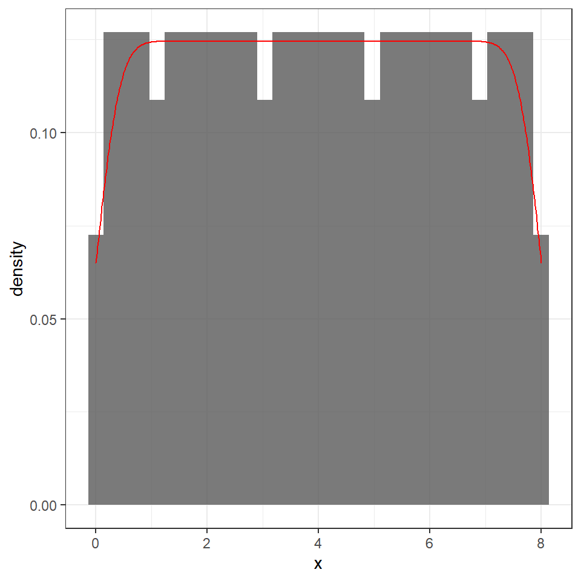

```r
tibble(x) %>%
  ggplot(aes(x)) +
  geom_histogram(aes(y=stat(density)), alpha=.8) + # add histogram
  geom_density(bw=0.35, color="red")
```

## e. Which model do you prefer, the parametric or KDE?

# Problem 2: Interstate Crash Density

Interstate 64 (I-64) is a major east-west road that passes just south of Charlottesville. Where and when are the most dangerous places/times to be on I-64? The crash data (link below) gives the mile marker and fractional time-of-week for crashes that occurred on I-64 between mile marker 87 and 136 in 2016. The time-of-week data takes a numeric value of *<dow>.<hour/24>*, where the dow starts at 0 for Sunday (6 for Sat) and the decimal gives the time of day information. Thus `time=0.0417` corresponds to Sun at 1am and `time=6.5` corresponds to Sat at noon.

- **Crash Data**: https://mdporter.github.io/SYS6018/data//crashes16.csv

## a. Extract the crashes and make a scatter plot with mile marker on x-axis and time on y-axis.

```r
crashdata = read.csv("crashes16.csv")
head(crashdata)
```

|  | mile | time |
| --- | --- | --- |
| 1 | 87.0 | 6.61875 |
| 2 | 118.0 | 6.70347 |
| 3 | 120.0 | 0.05486 |
| 4 | 90.0 | 0.20625 |
| 5 | 124.2 | 0.72569 |
| 6 | 118.0 | 3.88125 |

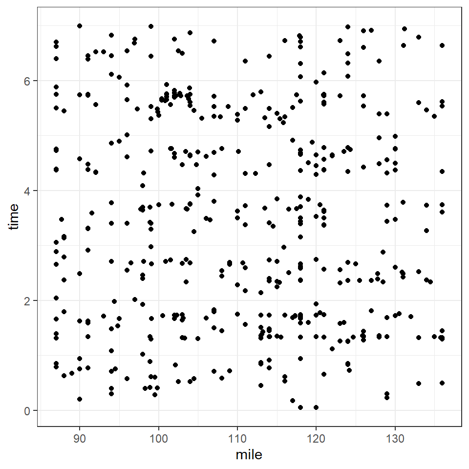

```r
ggplot(crashdata, aes(mile, time)) + geom_point()
```